# Laboratory 7 - Dummy Variables

Bayesian Statistics

Daniel Carpenter

March 2022

> **Goal**: Compare `Classical` and `Bayesian` approaches to estimate linear model containing dummy variables (categorical).  
> Useful techniques in setting up dummy variable via `model.matrix()`

# `Classical Estimation` with Categorical Valiables

## Categorical Variables Overview

In many applications we will need to incorporate categorical variables into our regression. How is this to be done?

```r
# Show the Data
data(mtcars)
head(mtcars)
```

```
##                    mpg cyl disp  hp drat    wt  qsec vs am gear carb
## Mazda RX4         21.0   6  160 110 3.90 2.620 16.46  0  1    4    4
## Mazda RX4 Wag     21.0   6  160 110 3.90 2.875 17.02  0  1    4    4
## Datsun 710        22.8   4  108  93 3.85 2.320 18.61  1  1    4    1
## Hornet 4 Drive    21.4   6  258 110 3.08 3.215 19.44  1  0    3    1
## Hornet Sportabout 18.7   8  360 175 3.15 3.440 17.02  0  0    3    2
## Valiant           18.1   6  225 105 2.76 3.460 20.22  1  0    3    1
```

```r
# Show the number of rows in mtcars
dim(mtcars)[1]
```

```
## [1] 32
```

We will define some variables to be factors

```r
# Convert categorical variables to factor class, store in `mycars`
mycars = within(mtcars, {
  cylF<-factor(cyl)
  vsF <- factor(vs)
  amF <- factor(am)
  gearF <- factor(gear)
  carbF <- factor(carb)
})

# See mycars after converting to factor class on cat. vars.
head(mycars)
```

```
##                    mpg cyl disp  hp drat    wt  qsec vs am gear carb carbF
## Mazda RX4         21.0   6  160 110 3.90 2.620 16.46  0  1    4    4     4
## Mazda RX4 Wag     21.0   6  160 110 3.90 2.875 17.02  0  1    4    4     4
## Datsun 710        22.8   4  108  93 3.85 2.320 18.61  1  1    4    1     1
## Hornet 4 Drive    21.4   6  258 110 3.08 3.215 19.44  1  0    3    1     1
## Hornet Sportabout 18.7   8  360 175 3.15 3.440 17.02  0  0    3    2     2
## Valiant           18.1   6  225 105 2.76 3.460 20.22  1  0    3    1     1
##                   gearF amF vsF cylF
## Mazda RX4             4   1   0    6
## Mazda RX4 Wag         4   1   0    6
## Datsun 710            4   1   1    4
## Hornet 4 Drive        3   0   1    6
## Hornet Sportabout     3   0   0    8
## Valiant               3   0   1    6
```

```r
# Notice how many cars in sample have x number of carbs
table(mycars$carbF)
```

```
##
##  1  2  3  4  6  8
##  7 10  3 10  1  1
```

## Using classical methods for Linear Model

```r
# Create a linear model: How does displacement and the number of carborators effect mpg
# Store in new var
mpglm = lm(mpg~disp + carbF, data =mycars )
summary(mpglm)
```

```
##
## Call:
## lm(formula = mpg ~ disp + carbF, data = mycars)
##
## Residuals:
##     Min      1Q  Median      3Q     Max
## -4.3359 -1.6135  0.0321  1.1194  6.3592
##
## Coefficients:
##              Estimate Std. Error t value Pr(>|t|)
## (Intercept) 30.014542   1.350232  22.229  < 2e-16 ***
## disp        -0.034793   0.005309  -6.554 7.26e-07 ***
## carbF2      -0.372064   1.545757  -0.241   0.8118
## carbF3      -4.118676   2.224379  -1.852   0.0759 .
## carbF4      -3.479816   1.759031  -1.978   0.0590 .
## carbF6      -5.269580   3.243950  -1.624   0.1168
## carbF8      -4.541896   3.362060  -1.351   0.1888
## ---
## Signif. codes:  0 '***' 0.001 '**' 0.01 '*' 0.05 '.' 0.1 ' ' 1
##
## Residual standard error: 3.034 on 25 degrees of freedom
## Multiple R-squared:  0.7956, Adjusted R-squared:  0.7466
## F-statistic: 16.22 on 6 and 25 DF,  p-value: 1.544e-07
```

## Model Matrix and Dummy Variables

We can extract the `design matrix` by using `model.matrix()`:

```r
# Create a model matrix, which converts the linear model object
# into a form which outlines the dummy variables for each factor in carborator
# IOnterpret as:
  # if 1, then it has x number of carborators,
  # Else if all 0, then the base (1 carborators, notice not in the file) is present in car
mm=model.matrix(mpglm)
df = as.data.frame(mm)

lst = as.list(df)
df
```

```
##                     (Intercept)  disp carbF2 carbF3 carbF4 carbF6 carbF8
## Mazda RX4                     1 160.0      0      0      1      0      0
## Mazda RX4 Wag                 1 160.0      0      0      1      0      0
## Datsun 710                    1 108.0      0      0      0      0      0
## Hornet 4 Drive                1 258.0      0      0      0      0      0
## Hornet Sportabout             1 360.0      1      0      0      0      0
## Valiant                       1 225.0      0      0      0      0      0
## Duster 360                    1 360.0      0      0      1      0      0
## Merc 240D                     1 146.7      1      0      0      0      0
## Merc 230                      1 140.8      1      0      0      0      0
## Merc 280                      1 167.6      0      0      1      0      0
## Merc 280C                     1 167.6      0      0      1      0      0
## Merc 450SE                    1 275.8      0      1      0      0      0
## Merc 450SL                    1 275.8      0      1      0      0      0
## Merc 450SLC                   1 275.8      0      1      0      0      0
## Cadillac Fleetwood            1 472.0      0      0      1      0      0
## Lincoln Continental           1 460.0      0      0      1      0      0
## Chrysler Imperial             1 440.0      0      0      1      0      0
## Fiat 128                      1  78.7      0      0      0      0      0
## Honda Civic                   1  75.7      1      0      0      0      0
## Toyota Corolla                1  71.1      0      0      0      0      0
## Toyota Corona                 1 120.1      0      0      0      0      0
## Dodge Challenger              1 318.0      1      0      0      0      0
## AMC Javelin                   1 304.0      1      0      0      0      0
## Camaro Z28                    1 350.0      0      0      1      0      0
## Pontiac Firebird              1 400.0      1      0      0      0      0
## Fiat X1-9                     1  79.0      0      0      0      0      0
## Porsche 914-2                 1 120.3      1      0      0      0      0
## Lotus Europa                  1  95.1      1      0      0      0      0
## Ford Pantera L                1 351.0      0      0      1      0      0
## Ferrari Dino                  1 145.0      0      0      0      1      0
## Maserati Bora                 1 301.0      0      0      0      0      1
## Volvo 142E                    1 121.0      1      0      0      0      0
```

Also see the data used in the model

```r
# See that you can also remake the original data frame
df2=model.frame(mpglm)
head(df2)
```

```
##                    mpg disp carbF
## Mazda RX4         21.0  160     4
## Mazda RX4 Wag     21.0  160     4
## Datsun 710        22.8  108     1
## Hornet 4 Drive    21.4  258     1
## Hornet Sportabout 18.7  360     2
## Valiant           18.1  225     1
```

```r
# Use dput to output the df in the form for JAGS model
# Can use this to encapsulate data and reproduce the data frame
dput(df2)
```

```
## structure(list(mpg = c(21, 21, 22.8, 21.4, 18.7, 18.1, 14.3,
## 24.4, 22.8, 19.2, 17.8, 16.4, 17.3, 15.2, 10.4, 10.4, 14.7, 32.4,
## 30.4, 33.9, 21.5, 15.5, 15.2, 13.3, 19.2, 27.3, 26, 30.4, 15.8,
## 19.7, 15, 21.4), disp = c(160, 160, 108, 258, 360, 225, 360,
## 146.7, 140.8, 167.6, 167.6, 275.8, 275.8, 275.8, 472, 460, 440,
## 78.7, 75.7, 71.1, 120.1, 318, 304, 350, 400, 79, 120.3, 95.1,
## 351, 145, 301, 121), carbF = structure(c(4L, 4L, 1L, 1L, 2L,
## 1L, 4L, 2L, 2L, 4L, 4L, 3L, 3L, 3L, 4L, 4L, 4L, 1L, 2L, 1L, 1L,
## 2L, 2L, 4L, 2L, 1L, 2L, 2L, 4L, 5L, 6L, 2L), .Label = c("1",
## "2", "3", "4", "6", "8"), class = "factor")), terms = mpg ~ disp +
##     carbF, row.names = c("Mazda RX4", "Mazda RX4 Wag", "Datsun 710",
## "Hornet 4 Drive", "Hornet Sportabout", "Valiant", "Duster 360",
## "Merc 240D", "Merc 230", "Merc 280", "Merc 280C", "Merc 450SE",
## "Merc 450SL", "Merc 450SLC", "Cadillac Fleetwood", "Lincoln Continental",
## "Chrysler Imperial", "Fiat 128", "Honda Civic", "Toyota Corolla",
## "Toyota Corona", "Dodge Challenger", "AMC Javelin", "Camaro Z28",
## "Pontiac Firebird", "Fiat X1-9", "Porsche 914-2", "Lotus Europa",
## "Ford Pantera L", "Ferrari Dino", "Maserati Bora", "Volvo 142E"
## ), class = "data.frame")
```

## Linear Model `LaTeX` Expression

$$y = \beta_0 + \beta_1 x + \beta_2 carbF2 + \beta_3 carbF3 + \beta_4 carbF4 + \beta_5 carbF6 + \beta_6 carbF8 + \epsilon$$

# `Bayesian Estimation` with Categorical Valiables

## Task 1: `OpenBUGS` Linear Model with `mtcars` dataset

- Make up the model file by using OpenBUGS and creating a doodle in the doodle editor. The model will be a regression (just modify the SLR model to include the dummy variables). Take a picture of the doodle once it checks out and place here using `![](.png){width=80%}`

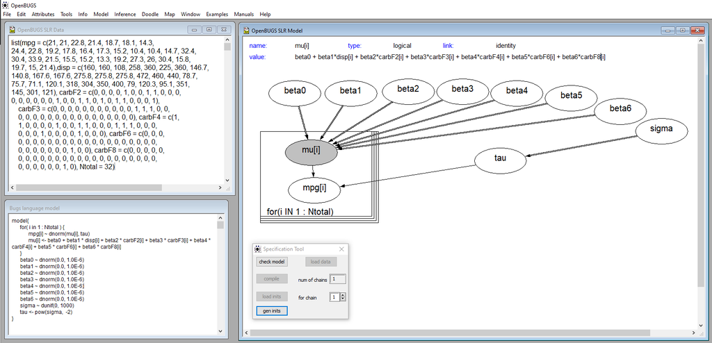

## Task 2: *Pretty Print* Model into `JAGS` Script

- Use `pretty print` (this will only work once the model is checked - use the menu!) and paste the model code into the modelString below: Fill in all other needed parameters and summarize the `codaSamples` using summary() – to run the chunk you will need to remove `eval=FALSE`

### JAGS Script with Pretty Printed Model

```r
# Get rid of the intercept
dput(df[,-1])
```

```
## structure(list(disp = c(160, 160, 108, 258, 360, 225, 360, 146.7,
## 140.8, 167.6, 167.6, 275.8, 275.8, 275.8, 472, 460, 440, 78.7,
## 75.7, 71.1, 120.1, 318, 304, 350, 400, 79, 120.3, 95.1, 351,
## 145, 301, 121), carbF2 = c(0, 0, 0, 0, 1, 0, 0, 1, 1, 0, 0, 0,
## 0, 0, 0, 0, 0, 0, 1, 0, 0, 1, 1, 0, 1, 0, 1, 1, 0, 0, 0, 1),
##     carbF3 = c(0, 0, 0, 0, 0, 0, 0, 0, 0, 0, 0, 1, 1, 1, 0, 0,
##     0, 0, 0, 0, 0, 0, 0, 0, 0, 0, 0, 0, 0, 0, 0, 0), carbF4 = c(1,
##     1, 0, 0, 0, 0, 1, 0, 0, 1, 1, 0, 0, 0, 1, 1, 1, 0, 0, 0,
##     0, 0, 0, 1, 0, 0, 0, 0, 1, 0, 0, 0), carbF6 = c(0, 0, 0,
##     0, 0, 0, 0, 0, 0, 0, 0, 0, 0, 0, 0, 0, 0, 0, 0, 0, 0, 0,
##     0, 0, 0, 0, 0, 0, 0, 1, 0, 0), carbF8 = c(0, 0, 0, 0, 0,
##     0, 0, 0, 0, 0, 0, 0, 0, 0, 0, 0, 0, 0, 0, 0, 0, 0, 0, 0,
##     0, 0, 0, 0, 0, 0, 1, 0)), class = "data.frame", row.names = c("Mazda RX4",
## "Mazda RX4 Wag", "Datsun 710", "Hornet 4 Drive", "Hornet Sportabout",
## "Valiant", "Duster 360", "Merc 240D", "Merc 230", "Merc 280",
## "Merc 280C", "Merc 450SE", "Merc 450SL", "Merc 450SLC", "Cadillac Fleetwood",
## "Lincoln Continental", "Chrysler Imperial", "Fiat 128", "Honda Civic",
## "Toyota Corolla", "Toyota Corona", "Dodge Challenger", "AMC Javelin",
## "Camaro Z28", "Pontiac Firebird", "Fiat X1-9", "Porsche 914-2",
## "Lotus Europa", "Ford Pantera L", "Ferrari Dino", "Maserati Bora",
## "Volvo 142E"))
```

```r
# BE SURE TO GET RID OF EVAL=FALSE
require(rjags)               # Must have previously installed package rjags.
```

```r
Ntotal = dim(mtcars)[1]
fileNameRoot="categotical" # For output file names. (from using dput)
dataList=list(mpg = c(21, 21, 22.8, 21.4, 18.7, 18.1, 14.3,
24.4, 22.8, 19.2, 17.8, 16.4, 17.3, 15.2, 10.4, 10.4, 14.7, 32.4,
30.4, 33.9, 21.5, 15.5, 15.2, 13.3, 19.2, 27.3, 26, 30.4, 15.8,
19.7, 15, 21.4),disp = c(160, 160, 108, 258, 360, 225, 360, 146.7,
140.8, 167.6, 167.6, 275.8, 275.8, 275.8, 472, 460, 440, 78.7,
75.7, 71.1, 120.1, 318, 304, 350, 400, 79, 120.3, 95.1, 351,
145, 301, 121), carbF2 = c(0, 0, 0, 0, 1, 0, 0, 1, 1, 0, 0, 0,
0, 0, 0, 0, 0, 0, 1, 0, 0, 1, 1, 0, 1, 0, 1, 1, 0, 0, 0, 1),
    carbF3 = c(0, 0, 0, 0, 0, 0, 0, 0, 0, 0, 0, 1, 1, 1, 0, 0,
    0, 0, 0, 0, 0, 0, 0, 0, 0, 0, 0, 0, 0, 0, 0, 0), carbF4 = c(1,
    1, 0, 0, 0, 0, 1, 0, 0, 1, 1, 0, 0, 0, 1, 1, 1, 0, 0, 0,
    0, 0, 0, 1, 0, 0, 0, 0, 1, 0, 0, 0), carbF6 = c(0, 0, 0,
    0, 0, 0, 0, 0, 0, 0, 0, 0, 0, 0, 0, 0, 0, 0, 0, 0, 0, 0,
    0, 0, 0, 0, 0, 0, 0, 1, 0, 0), carbF8 = c(0, 0, 0, 0, 0,
    0, 0, 0, 0, 0, 0, 0, 0, 0, 0, 0, 0, 0, 0, 0, 0, 0, 0, 0,
    0, 0, 0, 0, 0, 0, 1, 0), Ntotal = Ntotal)


#Define the model: -- >> define this using OPENBUGS <<
modelString = "
model{
    for( i in 1 : Ntotal ) {
        mpg[i] ~ dnorm(mu[i], tau)
        mu[i] <- beta0 + beta1 * disp[i] + beta2 * carbF2[i] + beta3 * carbF3[i] + beta4 * carbF4[i] + beta5 * carbF6[i] + beta6 * carbF8[i]
    }
    beta0 ~ dnorm(0.0, 1.0E-6)
    beta1 ~ dnorm(0.0, 1.0E-6)
    beta2 ~ dnorm(0.0, 1.0E-6)
    beta3 ~ dnorm(0.0, 1.0E-6)
    beta4 ~ dnorm(0.0, 1.0E-6)
    beta5 ~ dnorm(0.0, 1.0E-6)
    beta6 ~ dnorm(0.0, 1.0E-6)
    sigma ~ dunif(0, 1000)
    tau <- pow(sigma,  -2)
}
" # close quote for modelString
writeLines( modelString , con="TEMPmodel.txt" )

# Initialize the chains based on MLE of data.
# Option: Use single initial value for all chains:
#  thetaInit = sum(y)/length(y)
#  initsList = list( theta=thetaInit )

# >> Make sure that initial values are good <<
initsList = list(beta0 = 0, beta1 = 0, beta2=0, beta3=0, beta4=0, betaq5=0, beta6=0, sigma =10)

# Run the chains:
jagsModel = jags.model( file="TEMPmodel.txt" , data=dataList , inits=initsList ,
                        n.chains=3 , n.adapt=500 )
update( jagsModel , n.iter=500 )
codaSamples = coda.samples( jagsModel , variable.names=c("beta0", "beta1", "beta2",
                                                         "beta3", "beta4", "beta5", "beta6" ,"sigma") ,
                            n.iter=33340 )
save( codaSamples , file=paste0(fileNameRoot,"Mcmc.Rdata") )

summary(codaSamples)
```

```
##
## Iterations = 1001:34340
## Thinning interval = 1
## Number of chains = 3
## Sample size per chain = 33340
##
## 1. Empirical mean and standard deviation for each variable,
##    plus standard error of the mean:
##
##           Mean       SD  Naive SE Time-series SE
## beta0 30.00119 1.451257 4.589e-03      1.450e-02
## beta1 -0.03482 0.005738 1.814e-05      5.776e-05
## beta2 -0.35342 1.647714 5.210e-03      1.361e-02
## beta3 -4.09687 2.365723 7.480e-03      1.628e-02
## beta4 -3.45342 1.879579 5.943e-03      1.670e-02
## beta5 -5.23431 3.476266 1.099e-02      1.631e-02
## beta6 -4.52731 3.584822 1.134e-02      1.888e-02
## sigma  3.19892 0.486428 1.538e-03      2.828e-03
##
## 2. Quantiles for each variable:
##
##           2.5%      25%      50%     75%    97.5%
## beta0  27.1216 29.05611 30.00574 30.9468 32.86929
## beta1  -0.0462 -0.03857 -0.03484 -0.0311 -0.02343
## beta2  -3.6082 -1.43002 -0.34802  0.7251  2.89239
## beta3  -8.7526 -5.64131 -4.10482 -2.5454  0.58333
## beta4  -7.1611 -4.69133 -3.45658 -2.2284  0.26676
## beta5 -12.0661 -7.52434 -5.22961 -2.9631  1.67547
## beta6 -11.5424 -6.88963 -4.53862 -2.1870  2.57807
## sigma   2.4194  2.85702  3.14089  3.4749  4.30883
```